# Grupo 14_Trabajo_Final_Asignatura 3

#### **4.10 Graficamos el Método del Codo**

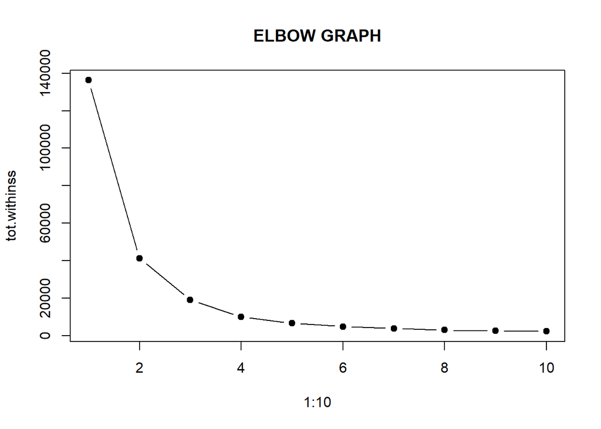

```r
plot(1:10, tot.withinss, type = "b", pch = 19,
     main = "ELBOW GRAPH")
```

Observamos que 3 es un buen número pues después del 3 la curva se vuelve más plana por lo que aumentar el número de clusters no aportará una mejora significativa.

#### **4.11 Visualizamos los clusters**

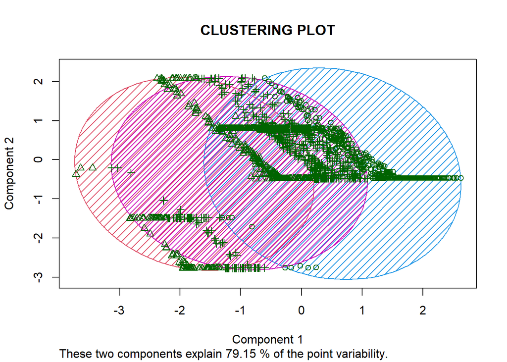

```r
library(cluster)
clusplot(data_clustering, clustering_result$cluster, color=TRUE, shade=TRUE, labels=0, lines=0, main = "CLUSTERING PLOT")
```

Observamos que hay claramente 3 grupos: rojo, rosa y azul. Se obseerva una superposición entre los clusters, principalmente el rojo y el rosa lo que nos quiere decir que los grupos no están perfectamente diferenciados y que puede haber patrones de comportamiento similares entre individuos de estos clusters.

#### **4.12 Visualizamos el Coeficiente de Silueta**

```r
library(factoextra)
```

```
##   cluster size ave.sil.width
## 1       1  648          0.59
## 2       2  501          0.65
## 3       3  962          0.53
```

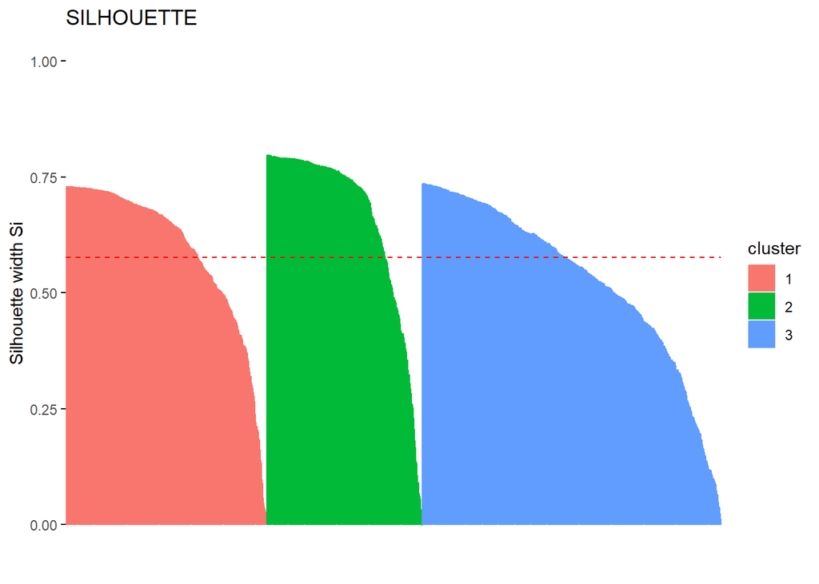

```r
fviz_silhouette(silhouette(clustering_result$cluster, dist(data_clustering)), main = "SILHOUETTE")
```

La mayoría de los puntos tienen valores mayores a 0.5, lo cual sugiere que el custering es aceptable. El cluster verde tiene los valores de silueta más altos indicando que los puntos están mejor definidos. El rojo presenta mayor variabilidad y el azul muestra una forma regular con valores medios.

#### **4.13 Calculamos la matriz de distancias usando el método “canberra”**

```r
dist_matrix <- dist(data_clustering, method = "canberra")
```

#### **4.14 Aplicamos el clustering jerárquico con el método “complete”**

```r
hclust_result <- hclust(dist_matrix, method = "complete")
```

#### **4.15 Visualizamos el dendrograma**

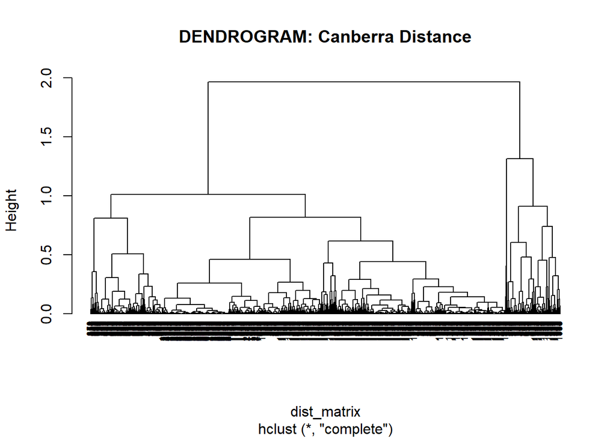

```r
plot(hclust_result, hang = -1, cex = 0.6, main = "DENDROGRAM: Canberra Distance")
```